# Mapping Reclamation: From Erasure to Healing

2025-05-14

# Setup

## Load Required Packages

```r
# Load necessary libraries
library(sf)          # For handling spatial vector data
library(tidyverse)   # For data manipulation and plotting
library(tmap)        # For thematic mapping
library(janitor)     # For clean column names
library(here)        # Helps manage file paths
library(dbscan)      # For hotspot clustering
library(leaflet)    # For creating interactive web maps
library(mapview)    # For exporting interactive web maps as images
library(spatstat)   # For conducting a cross-K function
library(ggplot2)    # For generating a cross-K function flow map
library(scales)     # For graphing visualizations
```

## Load Data

```r
# Set data folder path
data_folder <- "C:/Users/ianal/OneDrive/Documents/Academic/Hertie MPP/2025 Spring Semester/E14_Geospatial Analysis for Data Science/Data Analysis/Data Files"

# Load former residential school locations
irs <- st_read(file.path(data_folder, "IRS_Locations.shp"))
# Load Indigenous community infrastructure points
infrastructure <- st_read(file.path(data_folder, "Indigenous_community_infrastructure.shp"))
```

```r
# Load Canadian map
canada_map <- st_read(file.path(data_folder, "lpr_000b21a_e.shp"))
```

## Data Cleaning

```r
# Check structure of the datasets
glimpse(irs)
```

```
## Rows: 181
## Columns: 50
## $ OBJECTID   <dbl> 1, 2, 3, 4, 5, 6, 7, 8, 9, 10, 11, 12, 13, 14, 15, 16, 17, …
## $ SchoolID   <dbl> 1, 2, 3, 4, 5, 6, 7, 8, 9, 10, 11, 12, 13, 14, 15, 16, 17, …
## $ LocID      <dbl> 11, 21, 31, 41, 51, 61, 71, 81, 91, 101, 111, 121, 131, 141…
## $ AssocSch   <dbl> 0, 0, 0, 0, 0, 0, 0, 0, 0, 0, 0, 0, 0, 0, 0, 0, 0, 0, 0, 0,…
## $ NRCNamePri <chr> "Carcross", "Coudert Hall", "Shingle Point", "Whitehorse Ba…
## $ IRSSAEarYR <dbl> 1903, 1960, 1929, 1947, 1960, 1926, 1936, 1955, 1906, 1903,…
## $ IRSSALstYR <dbl> 1969, 1971, 1936, 1960, 1985, 1959, 1959, 1976, 1960, 1957,…
## $ LocName    <chr> "Carcross", "Coudert Hall", "Single Point", "Whitehorse Bap…
## $ AltNames   <chr> "Chooutla; Choutla Indian Residential School", "Whitehorse …
## $ LocEarlyYR <dbl> 1903, 1960, 1929, 1947, 1960, 1926, 1936, 1955, 1867, 1903,…
## $ LocLastYR  <dbl> 1969, 1971, 1936, 1960, 1985, 1959, 1959, 1976, 1960, 1957,…
## $ Latitude   <dbl> 60.17884, 60.70413, 68.99785, 60.71484, 60.70525, 68.21726,…
## $ Longitude  <dbl> -134.68543, -135.03633, -137.45593, -135.05426, -135.03761,…
```

[output cut: 37 more lines]

```r
glimpse(infrastructure)
```

```
## Rows: 25,931
## Columns: 15
## $ PROV_EN   <chr> "British Columbia", "British Columbia", "British Columbia", …
## $ COMM_EN   <chr> "?Akisq'nuk First Nation", "?Akisq'nuk First Nation", "?Akis…
## $ COMM_NUM  <chr> "604", "604", "604", "604", "604", "604", "604", "604", "604…
## $ COMM_TYPE <chr> "First Nation", "First Nation", "First Nation", "First Natio…
## $ PROJ_NUM  <chr> "9-00131096", "9-00131354", "9-00129742", "9-00125741", "9-0…
## $ TYPE_EN   <chr> "Solid Waste Management", "Housing", "Solid Waste Management…
## $ NAME_EN   <chr> "Workplan - Indigenous Zero Waste Technical Advisory Group -…
## $ DESC_EN   <chr> "Technical advisory services, waste operator training, waste…
## $ STATUS_EN <chr> "Ongoing", "Ongoing", "Completed", "Ongoing", "Ongoing", "Co…
## $ INV_EN    <chr> "Not Available", "Not Available", "$1,323,417.00", "Not Avai…
## $ INFO_EN   <chr> "Funding provided to an Indigenous organization or a Tribal …
## $ INFO2_EN  <chr> "Includes funding delivered under the Investing in Canada Pl…
## $ LONGITUDE <dbl> -115.964, -115.964, -115.964, -115.964, -115.964, -115.964, …
## $ LATITUDE  <dbl> 50.4585, 50.4585, 50.4585, 50.4585, 50.4585, 50.4585, 50.458…
## $ geometry  <POINT [°]> POINT (-124.4942 54.56625), POINT (-115.9082 50.41131)…
```

```r
# Check CRS (coordinate reference system)
st_crs(irs)
```

```
## Coordinate Reference System:
##   User input: WGS 84
##   wkt:
## GEOGCRS["WGS 84",
##     DATUM["World Geodetic System 1984",
##         ELLIPSOID["WGS 84",6378137,298.257223563,
##             LENGTHUNIT["metre",1]]],
##     PRIMEM["Greenwich",0,
##         ANGLEUNIT["degree",0.0174532925199433]],
##     CS[ellipsoidal,2],
##         AXIS["latitude",north,
##             ORDER[1],
##             ANGLEUNIT["degree",0.0174532925199433]],
##         AXIS["longitude",east,
##             ORDER[2],
##             ANGLEUNIT["degree",0.0174532925199433]],
##     ID["EPSG",4326]]
```

```r
st_crs(infrastructure)
```

```
## Coordinate Reference System:
##   User input: NAD83(CSRS)
##   wkt:
## GEOGCRS["NAD83(CSRS)",
##     DATUM["NAD83 Canadian Spatial Reference System",
##         ELLIPSOID["GRS 1980",6378137,298.257222101,
##             LENGTHUNIT["metre",1]]],
##     PRIMEM["Greenwich",0,
##         ANGLEUNIT["degree",0.0174532925199433]],
##     CS[ellipsoidal,2],
##         AXIS["geodetic latitude (Lat)",north,
##             ORDER[1],
##             ANGLEUNIT["degree",0.0174532925199433]],
##         AXIS["geodetic longitude (Lon)",east,
##             ORDER[2],
##             ANGLEUNIT["degree",0.0174532925199433]],
##     USAGE[
##         SCOPE["Horizontal component of 3D system."],
##         AREA["Canada - onshore and offshore - Alberta; British Columbia; Manitoba; New Brunswick; Newfoundland and Labrador; Northwest Territories; Nova Scotia; Nunavut; Ontario; Prince Edward Island; Quebec; Saskatchewan; Yukon."],
##         BBOX[38.21,-141.01,86.46,-40.73]],
##     ID["EPSG",4617]]
```

```r
# Reproject both datasets to Canada Lambert Conformal Conic to accurately represent local shapes and directions across much of the country
canada_crs <- 3347
canada_map_3347 <- st_transform(canada_map, crs = 3347)

irs_proj <- st_transform(irs, crs = canada_crs)
infrastructure_proj <- st_transform(infrastructure, crs = canada_crs)

# Check to confirm
st_crs(irs_proj)
```

```
## Coordinate Reference System:
##   User input: EPSG:3347
##   wkt:
## PROJCRS["NAD83 / Statistics Canada Lambert",
##     BASEGEOGCRS["NAD83",
##         DATUM["North American Datum 1983",
##             ELLIPSOID["GRS 1980",6378137,298.257222101,
##                 LENGTHUNIT["metre",1]]],
##         PRIMEM["Greenwich",0,
##             ANGLEUNIT["degree",0.0174532925199433]],
##         ID["EPSG",4269]],
##     CONVERSION["Statistics Canada Lambert",
##         METHOD["Lambert Conic Conformal (2SP)",
##             ID["EPSG",9802]],
##         PARAMETER["Latitude of false origin",63.390675,
##             ANGLEUNIT["degree",0.0174532925199433],
##             ID["EPSG",8821]],
##         PARAMETER["Longitude of false origin",-91.8666666666667,
##             ANGLEUNIT["degree",0.0174532925199433],
##             ID["EPSG",8822]],
##         PARAMETER["Latitude of 1st standard parallel",49,
##             ANGLEUNIT["degree",0.0174532925199433],
##             ID["EPSG",8823]],
##         PARAMETER["Latitude of 2nd standard parallel",77,
##             ANGLEUNIT["degree",0.0174532925199433],
##             ID["EPSG",8824]],
##         PARAMETER["Easting at false origin",6200000,
##             LENGTHUNIT["metre",1],
##             ID["EPSG",8826]],
##         PARAMETER["Northing at false origin",3000000,
##             LENGTHUNIT["metre",1],
##             ID["EPSG",8827]]],
##     CS[Cartesian,2],
##         AXIS["(E)",east,
##             ORDER[1],
##             LENGTHUNIT["metre",1]],
##         AXIS["(N)",north,
##             ORDER[2],
##             LENGTHUNIT["metre",1]],
##     USAGE[
##         SCOPE["Topographic mapping (small scale)."],
##         AREA["Canada - onshore and offshore - Alberta; British Columbia; Manitoba; New Brunswick; Newfoundland and Labrador; Northwest Territories; Nova Scotia; Nunavut; Ontario; Prince Edward Island; Quebec; Saskatchewan; Yukon."],
##         BBOX[38.21,-141.01,86.46,-40.73]],
##     ID["EPSG",3347]]
```

```r
st_crs(infrastructure_proj)
```

```
## Coordinate Reference System:
##   User input: EPSG:3347
##   wkt:
## PROJCRS["NAD83 / Statistics Canada Lambert",
##     BASEGEOGCRS["NAD83",
##         DATUM["North American Datum 1983",
##             ELLIPSOID["GRS 1980",6378137,298.257222101,
##                 LENGTHUNIT["metre",1]]],
##         PRIMEM["Greenwich",0,
##             ANGLEUNIT["degree",0.0174532925199433]],
##         ID["EPSG",4269]],
##     CONVERSION["Statistics Canada Lambert",
##         METHOD["Lambert Conic Conformal (2SP)",
##             ID["EPSG",9802]],
##         PARAMETER["Latitude of false origin",63.390675,
##             ANGLEUNIT["degree",0.0174532925199433],
##             ID["EPSG",8821]],
##         PARAMETER["Longitude of false origin",-91.8666666666667,
##             ANGLEUNIT["degree",0.0174532925199433],
##             ID["EPSG",8822]],
##         PARAMETER["Latitude of 1st standard parallel",49,
##             ANGLEUNIT["degree",0.0174532925199433],
##             ID["EPSG",8823]],
##         PARAMETER["Latitude of 2nd standard parallel",77,
##             ANGLEUNIT["degree",0.0174532925199433],
##             ID["EPSG",8824]],
##         PARAMETER["Easting at false origin",6200000,
##             LENGTHUNIT["metre",1],
##             ID["EPSG",8826]],
##         PARAMETER["Northing at false origin",3000000,
##             LENGTHUNIT["metre",1],
##             ID["EPSG",8827]]],
##     CS[Cartesian,2],
##         AXIS["(E)",east,
##             ORDER[1],
##             LENGTHUNIT["metre",1]],
##         AXIS["(N)",north,
##             ORDER[2],
##             LENGTHUNIT["metre",1]],
##     USAGE[
##         SCOPE["Topographic mapping (small scale)."],
##         AREA["Canada - onshore and offshore - Alberta; British Columbia; Manitoba; New Brunswick; Newfoundland and Labrador; Northwest Territories; Nova Scotia; Nunavut; Ontario; Prince Edward Island; Quebec; Saskatchewan; Yukon."],
##         BBOX[38.21,-141.01,86.46,-40.73]],
##     ID["EPSG",3347]]
```

## Create Buffer Zones

```r
# Create buffers at various distances (in meters)
irs_1km <- st_buffer(irs_proj, dist = 1000) %>% mutate(buffer_km = 1)
irs_5km <- st_buffer(irs_proj, dist = 5000) %>% mutate(buffer_km = 5)
irs_10km <- st_buffer(irs_proj, dist = 10000) %>% mutate(buffer_km = 10)
irs_20km <- st_buffer(irs_proj, dist = 20000) %>% mutate(buffer_km = 20)
irs_50km <- st_buffer(irs_proj, dist = 50000) %>% mutate(buffer_km = 50)

# Combine all into a single sf object
irs_buffers <- bind_rows(irs_1km, irs_5km, irs_10km, irs_20km, irs_50km)
```

# Section 1: Primary Analysis

The purpose of this analysis is to explore the geospatial relationship between former Canadian Indigenous residential school sites (IRS) and current Indigenous-led infrastructure projects (IIPs). In particular, point pattern comparisons and Cross-K functions are conducted in order to determine if areas surrounding former IRS sites are experiencing notable investment in Indigenous-led infrastructure projects. Such actions reflect broader efforts at cultural, social, and spatial reclamation that have been discussed in topic literature.

## High-Level Overview: Projects per Buffer Zone

The below table summarizes the number of IIPs within each defined “nearby” buffer of 1, 5, 10, 20, and 50km, as well as the number of IIPs outside this threshold.

```r
# Spatial join: match infrastructure points to buffers
infrastructure_joined <- st_join(infrastructure_proj, irs_buffers, join = st_within)

# Count how many infrastructure projects fall within each buffer
infrastructure_counts <- infrastructure_joined %>%
  st_drop_geometry() %>%
  group_by(buffer_km) %>%
  summarise(projects_within = n())

infrastructure_counts
```

```
## # A tibble: 6 × 2
##   buffer_km projects_within
##       <dbl>           <int>
## 1         1            3154
## 2         5            4747
## 3        10            7058
## 4        20           11015
## 5        50           17082
## 6        NA           15114
```

While the results reveal that the number of IIPs increases with distance,the cumulative number of projects within 50 km of former IRS sites is greater than those beyond.

## Buffer Zone Composition by Project Category

Since “infrastructure” projects can include both practical municipal installments (such as water and waste management) as well as socio-cultural community development initiatives (such as those related to recreation, health, and education), it is meaningful to investigate what types of projects dominate within different distance bands.

```r
# Summarize: Count by category and buffer
infrastructure_by_category <- infrastructure_joined %>%
  st_drop_geometry() %>%
  group_by(buffer_km, TYPE_EN) %>%
  summarise(projects = n(), .groups = "drop") %>%
  arrange(buffer_km, desc(projects))

infrastructure_by_category
```

```
## # A tibble: 90 × 3
##    buffer_km TYPE_EN                      projects
##        <dbl> <chr>                           <int>
##  1         1 Housing                          1257
##  2         1 Transfer of Service Delivery      762
##  3         1 Solid Waste Management            475
##  4         1 Water and Wastewater              276
##  5         1 Other Community Initiatives       104
##  6         1 School Facilities                  65
##  7         1 Health                             56
##  8         1 Fire Protection                    50
##  9         1 Roads and Bridges                  30
## 10         1 Connectivity                       29
## # ℹ 80 more rows
```

## Figure 1: Overlaying Buffer Zone Counts with Project Type Volumes

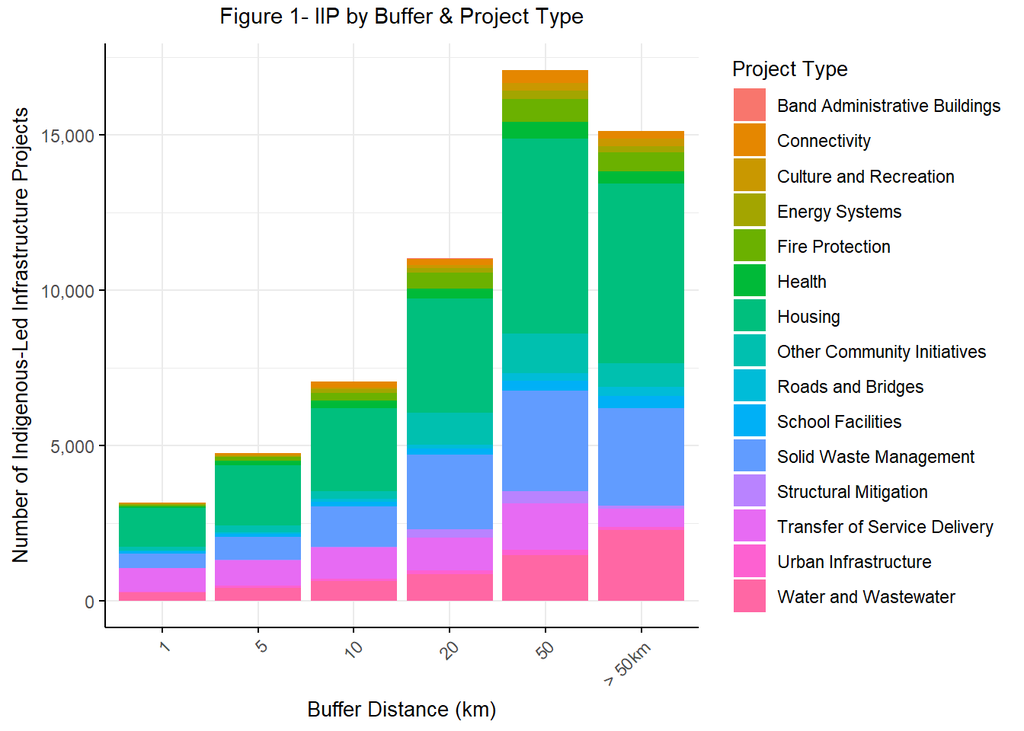

```r
Figure_1 <- ggplot(infrastructure_by_category, aes(x = factor(buffer_km), y = projects, fill = TYPE_EN)) +
  geom_bar(stat = "identity") +
  labs(
    x = "Buffer Distance (km)",
    y = "Number of Indigenous-Led Infrastructure Projects",
    title = "Figure 1- IIP by Buffer & Project Type",
    fill = "Project Type",
  ) +
  scale_x_discrete(labels = c("1", "5", "10", "20", "50", "> 50km")) +
  scale_y_continuous(labels = comma) +
  theme_minimal() +
  theme(
    axis.text.x = element_text(angle = 45, hjust = 1),
    axis.title.x = element_text(size = 10, margin = margin(t = 5)),
    axis.title.y = element_text(size = 10, margin = margin(r = 5)),
    axis.line = element_line(color = "black", linewidth = 0.5),
    axis.ticks = element_line(color = "black", linewidth = 0.5),
    plot.title = element_text(hjust = 0.5, vjust = 2, size = 11),
    legend.title = element_text(size = 10)
  )

Figure_1
```

```r
# Save the plot as a PNG file
ggsave("Figure 1- IIP by Buffer & Project Type.png", plot = Figure_1, width = 10, height = 6, units = "in", dpi = 300)
```

This stacked bar graph demonstrates the findings noted above: (1) IIP volume increases with buffer zone level, (2) total IIPs within 50 km of IRS sites is greater than those beyond this threshold, and (3) there is a considerable amount of socio-cultural projects (brown to teal colours) that hint at symbolic forms of spatial reclamation.

## Figure 2: Map of High-Reclamation IRS Sites

For future policy discussions and program development, it is useful to know where the “most reclaimed” IRS site are located across Canada.

```r
# Count projects within 10 km of each IRS site
irs_10km <- st_buffer(irs_proj, dist = 10000) %>%
  mutate(irs_id = row_number())

projects_per_site <- st_join(infrastructure_proj, irs_10km, join = st_within) %>%
  st_drop_geometry() %>%
  group_by(irs_id) %>%
  summarise(n_projects = n(), .groups = "drop")

# Select top 5 IRS sites by number of nearby projects
top_reclaimed_ids <- projects_per_site %>%
  arrange(desc(n_projects)) %>%
  slice_head(n = 5) %>%
  pull(irs_id)

# Highlight these on the map
top_irs_sites <- irs_proj %>%
  mutate(irs_id = row_number()) %>%
  filter(irs_id %in% top_reclaimed_ids)

# Map all IRS sites in gray, top 5 in red
leaflet() %>%
  addProviderTiles("CartoDB.Positron") %>%
  addCircleMarkers(data = st_transform(irs_proj, 4326),  # all sites
                   radius = 3, color = "gray", stroke = FALSE, fillOpacity = 0.6) %>%
  addCircleMarkers(data = st_transform(top_irs_sites, 4326),  # top 5
                   radius = 6, color = "red", stroke = TRUE, fillOpacity = 0.9,
                   label = ~paste("Top IRS site", irs_id)) %>%
  setView(lng = -95, lat = 55, zoom = 3)
```

[interactive chart not shown]

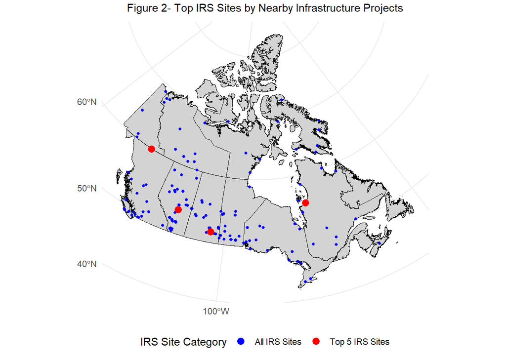

```r
leaflet_map <- leaflet() %>%
  addProviderTiles("CartoDB.Positron") %>%
  addCircleMarkers(data = st_transform(irs_proj, 4326),  # all sites
                   radius = 3, color = "gray", stroke = FALSE, fillOpacity = 0.6) %>%
  addCircleMarkers(data = st_transform(top_irs_sites, 4326),  # top 5
                   radius = 6, color = "red", stroke = TRUE, fillOpacity = 0.9,
                   label = ~paste("Top IRS site", irs_id)) %>%
  setView(lng = -95, lat = 55, zoom = 3)


# Save the map into a static image
Figure_2 <- ggplot() +
  geom_sf(data = canada_map_3347, fill = "lightgray", color = "black") +
  geom_sf(data = st_transform(irs_proj, crs = st_crs(canada_map_3347)),
          aes(color = "All IRS Sites"), size = 1) +
  geom_sf(data = st_transform(top_irs_sites, crs = st_crs(canada_map_3347)),
          aes(color = "Top 5 IRS Sites"), size = 3) +
  scale_color_manual(values = c("All IRS Sites" = "blue", "Top 5 IRS Sites" = "red"),
                     name = "IRS Site Category") +
  coord_sf(crs = 3347) +
  labs(title = "Figure 2- Top IRS Sites by Nearby Infrastructure Projects") +
  theme_minimal() +
  theme(
    plot.title = element_text(hjust = 0.5, vjust = 2, size = 11),
    legend.position = "bottom")

Figure_2
```

```r
# Save the plot as a PNG file
ggsave("Figure 2- Map of High Reclamation IRS Sites.png", plot = Figure_2, width = 10, height = 6, units = "in", dpi = 300)
```

Rather than concentrated in a specific region, the top 5 most reclaimed IRS sites are spread across the country. This knowledge can serve as the starting point for further research to see how effectively other truth and reconciliation efforts are implemented in these areas.

## Cross-K Analysis

Conducting a cross-k function will help identify any statistically significant correlations between point patterns by checking if point patterns cluster at the same locations.

### Figure 3: Spatial Statistics

The plot shows the estimated cross-K function, $\hat{K}_{irs,infrastructure}(r)$ (representing the main result: cross-K function between IRS and infrastructure), as the solid black line (labeled $\hat{K}_{irs,infrastructure}^{iso}(r)$ which stands for isotropic correction, a type of edge correction that tries to account for this bias in a way that assumes the pattern is the same in all directions. The x-axis represents the distance $r$, and the y-axis represents the value of the cross-K function at that distance.

The other lines on the plot represent different edge correction methods ($\hat{K}_{irs,infrastructure}^{trans}(r)$ for translation correction and $\hat{K}_{irs,infrastructure}^{bord}(r)$ for border correction). As can be seen, these should lines are reasonably close to each other- which is ideal. The blue dashed line ($\hat{K}_{irs,infrastructure}^{pois}(r)$) represents the theoretical value of the cross-K function under the null hypothesis of complete spatial randomness (CSR) and independence between the two point patterns.

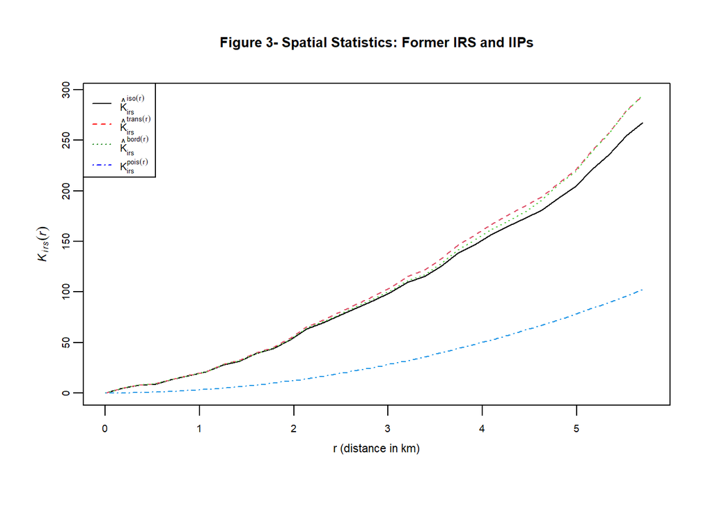

```r
# Extract bounding boxes from the sf objects
irs_bbox <- st_bbox(irs)
infrastructure_bbox <- st_bbox(infrastructure)

# Determine the overall extent by finding the minimum and maximum of all coordinates
xmin <- min(irs_bbox["xmin"], infrastructure_bbox["xmin"])
xmax <- max(irs_bbox["xmax"], infrastructure_bbox["xmax"])
ymin <- min(irs_bbox["ymin"], infrastructure_bbox["ymin"])
ymax <- max(irs_bbox["ymax"], infrastructure_bbox["ymax"])

# Define the observation window
window <- owin(c(xmin, xmax), c(ymin, ymax))

# Create ppp objects using the extracted coordinates
irs_coords <- st_coordinates(irs)
infrastructure_coords <- st_coordinates(infrastructure)

irs_ppp <- ppp(x = irs_coords[, 1], y = irs_coords[, 2], window = window)
infrastructure_ppp <- ppp(x = infrastructure_coords[, 1], y = infrastructure_coords[, 2], window = window)

# Combine coordinates
all_x <- c(irs_coords[, 1], infrastructure_coords[, 1])
all_y <- c(irs_coords[, 2], infrastructure_coords[, 2])

# Create a vector of marks indicating the type of each point
all_types <- c(rep("irs", nrow(irs_coords)), rep("infrastructure", nrow(infrastructure_coords)))

# Create a multitype ppp object
all_points_marked <- ppp(x = all_x, y = all_y, window = window, marks = factor(all_types))

# Define a sequence of distances (r)
max_distance <- diff(range(window$x)) / 5
r_values <- seq(0, max_distance, length.out = 100)

# Calculate the cross-K function
cross_K <- Kcross(all_points_marked, i = "irs", j = "infrastructure", r = r_values)

plot(cross_K,
     main = "Figure 3- Spatial Statistics: Former IRS and IIPs",
     cex.main = 0.8,
     cex.lab = 0.7,
     cex.axis = 0.6,
     xlab = "r (distance in km)",
     ylab = expression(K[irs, infrastructure](r)),
     legend = FALSE,
     mgp = c(1.5, 0.5, 0)
)

# Adding and formatting legend
legend("topleft",
       legend = c(expression(hat(K)[irs, infrastructure]^{iso}(r)),
                  expression(hat(K)[irs, infrastructure]^{trans}(r)),
                  expression(hat(K)[irs, infrastructure]^{bord}(r)),
                  expression(K[irs, infrastructure]^{pois}(r))),
       lty = c(1, 2, 3, 4),
       col = c("black", "red", "forestgreen", "blue"),
       cex = 0.6
)
```

The below code is simply to export the above graph.

```r
# Printing as PNG
dev.off()
```

```r
# Print a confirmation message
print("Cross-K function plot saved as cross_k_function.png")
```

```
## [1] "Cross-K function plot saved as cross_k_function.png"
```

### Figure 4: Geographically Weighted Flow Cross-K Function

A geographically weighted flow cross-k function in order to see the previous findings visualized as a map.

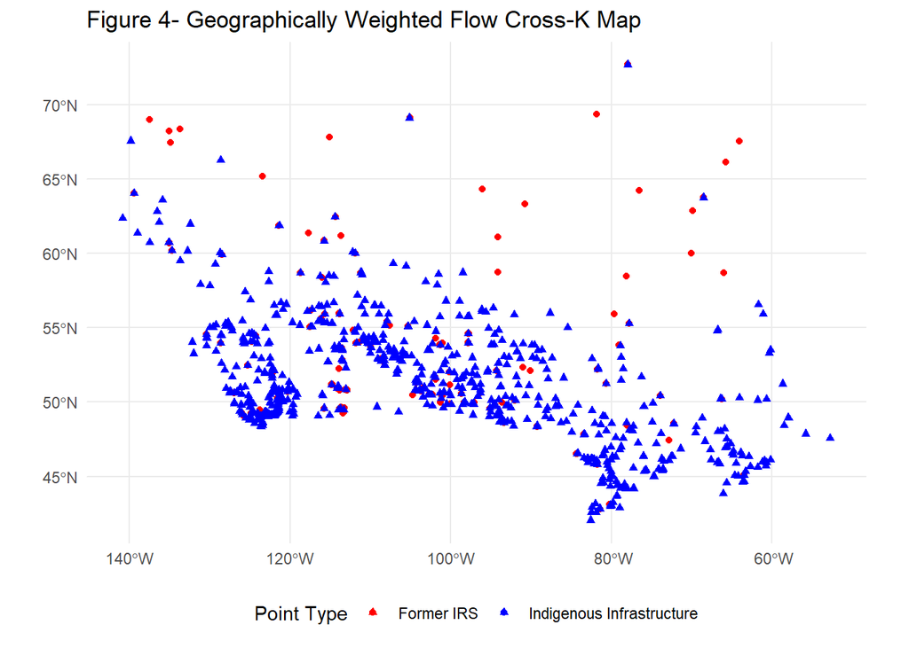

```r
# Create map using ggplot2
ggplot() +
  geom_sf(data = irs, aes(color = "Former IRS"), size = 1.5, shape = 16) +
  geom_sf(data = infrastructure, aes(color = "Indigenous Infrastructure"), size = 1.5, shape = 17) +
  scale_color_manual(name = "Point Type",  # Set the legend title
                     values = c("Former IRS" = "red", "Indigenous Infrastructure" = "blue")) +
  labs(title = "Figure 4- Geographically Weighted Flow Cross-K Map") +
  theme_minimal() +
  theme(legend.position = "bottom")
```

```r
leaflet() %>%
  addTiles() %>% # Add default OpenStreetMap tiles
  addCircleMarkers(data = irs,
                   color = "red",
                   radius = 5,
                   fillOpacity = 0.8,
                   label = "Former IRS") %>%
  addCircleMarkers(data = infrastructure,
                   color = "blue",
                   radius = 5,
                   fillOpacity = 0.8,
                   label = "Indigenous Infrastructure") %>%
  addLegend(position = "bottomright",
            colors = c("red", "blue"),
            labels = c("Former IRS", "Indigenous Infrastructure"))
```

[interactive chart not shown]

```r
irs_transformed <- st_transform(irs, crs = st_crs(canada_map_3347))
infrastructure_transformed <- st_transform(infrastructure, crs = st_crs(canada_map_3347))

# Save map into a static image
Figure_4 <- ggplot() +
  geom_sf(data = canada_map_3347, fill = "lightgray", color = "black") +
  geom_sf(data = irs_transformed, aes(color = "Former IRS"), size = 1.5, shape = 16) +
  geom_sf(data = infrastructure_transformed, aes(color = "Indigenous Infrastructure"), size = 1.5, shape = 17) +
  scale_color_manual(name = "Point Type",  # Set the legend title
                     values = c("Former IRS" = "red", "Indigenous Infrastructure" = "blue")) +
  labs(title = "Figure 4- Geographically Weighted Flow Cross-K Map") +
  theme_minimal() +
  theme(legend.position = "bottom")

# Save the ggplot2 map as a PNG file
ggsave("Figure 4- Geographically Weighted Flow Cross-K Map.png", plot = Figure_4, width = 10, height = 8, units = "in", dpi = 300)

# Confirmation message
print("Figure 4- Geographically Weighted Flow Cross-K Map.png")
```

```
## [1] "Figure 4- Geographically Weighted Flow Cross-K Map.png"
```

As described above, there are clear clusters of IIPs atop where former IRS sites used to be. In line with topic literature (McBain, 2021), this analysis finds that former IRS sites are experiencing notable investment in nearby IIPs, which reflects broader efforts at cultural, social, and spatial land reclamation. These transformations are vital to healing as they encourage reconnection with erased cultural landscapes [and challenge] current Eurocentric conservation practices” (McBain, 2021).

# Section 2: Data Sources/References

Canadian Map – Provinces & Territories Dataset (DOI: https://www12.statcan.gc.ca/census-recensement/alternative_alternatif.cfm)

Former IRS site data from the Borealis Data Repository (DOI: 10.5683/SP2/FJG5TG)

Indigenous Services Canada’s IIP Dataset (DOI: geo.sac-isc.gc.ca)

McBain, C. (2021). De-Colonial Intersections of Conservation and Healing: The Indian Residential School System (Doctoral dissertation, Carleton University).

# Section 3: Appendix- Further Analysis

The scope of this assignment and research question limits the number of figures included in the primary analysis. However, given the importance of reconciliation and reclamation efforts in Canada today, the below analyses contribute to research in the space to support healing and data-driven policymaking and program development.

## Buffer Breakdown by Province/Territory

Question: Are some provinces more active in reclaiming land near former IRS sites?

```r
# Group and count by province and buffer distance
infrastructure_by_province <- infrastructure_joined %>%
  st_drop_geometry() %>%
  group_by(PROV_EN, buffer_km) %>%
  summarise(projects = n(), .groups = "drop") %>%
  arrange(PROV_EN, buffer_km)

infrastructure_by_province
```

```
## # A tibble: 77 × 3
##    PROV_EN          buffer_km projects
##    <chr>                <dbl>    <int>
##  1 Alberta                  1      386
##  2 Alberta                  5     1012
##  3 Alberta                 10     1499
##  4 Alberta                 20     2164
##  5 Alberta                 50     3603
##  6 Alberta                 NA     1154
##  7 British Columbia         1      620
##  8 British Columbia         5      817
##  9 British Columbia        10     1002
## 10 British Columbia        20     3384
## # ℹ 67 more rows
```

This table breaks down infrastructure projects by buffer distance and province, revealing spatial variation across regions. Some provinces, such as British Columbia and Alberta, show strong project clustering near IRS sites, while others show more dispersed patterns - reflecting regional differences in historical settlement, school density, and funding allocation.

```r
# Create count of IRS sites per province (using PROV_EN)
irs_by_province <- irs_proj %>%
  st_drop_geometry() %>%
  rename(PROV_EN = Province) %>%   # ensure naming matches
  group_by(PROV_EN) %>%
  summarise(n_schools = n(), .groups = "drop")

# Create lookup table
prov_lookup <- tibble(
  PROV_EN = c("AB", "BC", "MB", "NB", "NL", "NS", "NT", "NU", "ON", "PE", "QC", "SK", "YT"),
  province_full = c(
    "Alberta", "British Columbia", "Manitoba", "New Brunswick", "Newfoundland and Labrador",
    "Nova Scotia", "Northwest Territories", "Nunavut", "Ontario", "Prince Edward Island",
    "Quebec", "Saskatchewan", "Yukon"
  )
)

# Add province_full to both datasets
infrastructure_by_province_named <- infrastructure_by_province %>%
  left_join(prov_lookup, by = "PROV_EN")

irs_by_province_named <- irs_by_province %>%
  left_join(prov_lookup, by = "PROV_EN")

# Summarize IRS sites per province (1 row per province_full)
irs_by_province_summarized <- irs_by_province_named %>%
  group_by(province_full) %>%
  summarise(n_schools = sum(n_schools), .groups = "drop")

# Join and calculate projects per school
province_normalized <- infrastructure_by_province_named %>%
  left_join(irs_by_province_summarized, by = "province_full") %>%
  mutate(projects_per_school = round(projects / n_schools, 2))

# View result
province_normalized
```

```
## # A tibble: 77 × 6
##    PROV_EN        buffer_km projects province_full n_schools projects_per_school
##    <chr>              <dbl>    <int> <chr>             <int>               <dbl>
##  1 Alberta                1      386 <NA>                 19                20.3
##  2 Alberta                5     1012 <NA>                 19                53.3
##  3 Alberta               10     1499 <NA>                 19                78.9
##  4 Alberta               20     2164 <NA>                 19               114.
##  5 Alberta               50     3603 <NA>                 19               190.
##  6 Alberta               NA     1154 <NA>                 19                60.7
##  7 British Colum…         1      620 <NA>                 19                32.6
##  8 British Colum…         5      817 <NA>                 19                43
##  9 British Colum…        10     1002 <NA>                 19                52.7
## 10 British Colum…        20     3384 <NA>                 19               178.
## # ℹ 67 more rows
```

```r
# Unique values in each dataset
unique(infrastructure_by_province$PROV_EN)
```

```
##  [1] "Alberta"                   "British Columbia"
##  [3] "Manitoba"                  "Newfoundland and Labrador"
##  [5] "New Brunswick"             "Northwest Territories"
##  [7] "Nova Scotia"               "Nunavut"
##  [9] "Ontario"                   "Prince Edward Island"
## [11] "Quebec"                    "Saskatchewan"
## [13] "Yukon"
```

```r
unique(irs_by_province$PROV_EN)
```

```
##  [1] "AB"  "BC"  "MB"  "NS"  "NT"  "NU"  "NWT" "ON"  "QC"  "SK"  "YK"
```

## IRS Site-Level Reclamation Density

Question: Which former schools have the highest concentration of surrounding projects?

```r
# Create 10km buffer around each IRS site with unique ID
irs_10km <- st_buffer(irs_proj, dist = 10000) %>%
  mutate(irs_id = row_number())

# Join projects to IRS sites using the 10km buffer
projects_per_site <- st_join(infrastructure_proj, irs_10km, join = st_within)

# Count projects per IRS site
projects_per_site_summary <- projects_per_site %>%
  st_drop_geometry() %>%
  group_by(irs_id) %>%
  summarise(projects_nearby = n(), .groups = "drop") %>%
  arrange(desc(projects_nearby))

projects_per_site_summary
```

```
## # A tibble: 128 × 2
##    irs_id projects_nearby
##     <int>           <int>
##  1     NA           20164
##  2    159            1338
##  3     44             878
##  4     92             793
##  5     60             143
##  6     37             136
##  7     67             134
##  8    176             134
##  9    177             134
## 10    146             132
## # ℹ 118 more rows
```

```r
# Join back with original IRS data to get names
projects_per_site_summary_named <- projects_per_site_summary %>%
  left_join(
    irs_proj %>% mutate(irs_id = row_number()) %>% st_drop_geometry() %>%
      select(irs_id, NRCNamePri),
    by = "irs_id"
  ) %>%
  select(NRCNamePri, projects_nearby) %>%
  arrange(desc(projects_nearby))

projects_per_site_summary_named
```

```
## # A tibble: 128 × 2
##    NRCNamePri                          projects_nearby
##    <chr>                                         <int>
##  1 <NA>                                          20164
##  2 Federal Hostel at Great Whale River            1338
##  3 Lower Post                                      878
##  4 Lebret                                          793
##  5 Ermineskin                                      143
##  6 Coqualeetza                                     136
##  7 Morley                                          134
##  8 <NA>                                            134
##  9 <NA>                                            134
## 10 St. Mary's                                      132
## # ℹ 118 more rows
```

This summary identifies former IRS sites with the most and fewest nearby infrastructure projects (within 10km). The variation between sites highlights uneven spatial patterns of reclamation. Sites with no or few nearby projects may represent under-recognized areas of potential cultural revitalization or indicate differing local priorities.

## Distance-to-Nearest IRS Site

Question: How close is each infrastructure project to the nearest former IRS site?

```r
# Calculate pairwise distances (in meters)
distance_matrix <- st_distance(infrastructure_proj, irs_proj)

# Get the minimum distance to any IRS site for each project
infrastructure_proj$min_distance_m <- apply(distance_matrix, 1, min)

# Convert meters to kilometers
infrastructure_proj$min_distance_km <- round(infrastructure_proj$min_distance_m / 1000, 2)

# Summarize distance statistics
infrastructure_proj %>%
  st_drop_geometry() %>%
  summarise(
    mean_distance_km = mean(min_distance_km),
    median_distance_km = median(min_distance_km),
    min_distance_km = min(min_distance_km),
    max_distance_km = max(min_distance_km)
  )
```

[output not shown]

```r
infrastructure_proj
```

```
## Simple feature collection with 25931 features and 16 fields
## Geometry type: POINT
## Dimension:     XY
## Bounding box:  xmin: 3732865 ymin: 702607.1 xmax: 8980371 ymax: 4165226
## Projected CRS: NAD83 / Statistics Canada Lambert
## First 10 features:
##             PROV_EN                 COMM_EN COMM_NUM    COMM_TYPE   PROJ_NUM
## 1  British Columbia ?Akisq'nuk First Nation      604 First Nation 9-00131096
## 2  British Columbia ?Akisq'nuk First Nation      604 First Nation 9-00131354
## 3  British Columbia ?Akisq'nuk First Nation      604 First Nation 9-00129742
## 4  British Columbia ?Akisq'nuk First Nation      604 First Nation 9-00125741
## 5  British Columbia ?Akisq'nuk First Nation      604 First Nation 9-00132074
## 6  British Columbia ?Akisq'nuk First Nation      604 First Nation 9-00129160
## 7  British Columbia ?Akisq'nuk First Nation      604 First Nation      CIB05
## 8  British Columbia ?Akisq'nuk First Nation      604 First Nation 9-00126357
```

[output cut: 79 more lines]

## Density Ratios: Projects Per Square KM

Question: Are projects more spatially dense near IRS sites, or further away?

```r
# Calculate total area per buffer_km (in km²)
buffer_areas <- irs_buffers %>%
  mutate(area_km2 = as.numeric(st_area(geometry)) / 1e6) %>%
  st_drop_geometry() %>%
  group_by(buffer_km) %>%
  summarise(total_area_km2 = sum(area_km2), .groups = "drop")

# Reuse the infra_counts data (number of projects per buffer_km)
# Make sure infra_counts exists from previous steps

# Join counts with areas and compute density
density_summary <- left_join(infrastructure_counts, buffer_areas, by = "buffer_km") %>%
  mutate(
    projects_per_km2 = round(projects_within / total_area_km2, 4)
  ) %>%
  arrange(buffer_km)

density_summary
```

```
## # A tibble: 6 × 4
##   buffer_km projects_within total_area_km2 projects_per_km2
##       <dbl>           <int>          <dbl>            <dbl>
## 1         1            3154           568.           5.55
## 2         5            4747         14209.           0.334
## 3        10            7058         56837.           0.124
## 4        20           11015        227347.           0.0485
## 5        50           17082       1420921.           0.012
## 6        NA           15114            NA           NA
```

This table calculates project density (projects per square kilometer) for each buffer zone. It shows a steep decline in density as distance increases from the IRS sites - indicating a strong spatial concentration of projects in areas closest to former schools. This supports the hypothesis that land reclamation efforts are geographically targeted toward these historical sites.

## Buffer Ring Analysis

Question: How does the number of infrastructure projects change across distance bands from former IRS sites?

```r
# Ensure counts are sorted
infrastructure_ring <- infrastructure_counts %>%
  arrange(buffer_km) %>%
  mutate(
    ring_label = case_when(
      buffer_km == 1 ~ "0–1 km",
      buffer_km == 5 ~ "1–5 km",
      buffer_km == 10 ~ "5–10 km",
      buffer_km == 20 ~ "10–20 km",
      buffer_km == 50 ~ "20–50 km",
      TRUE ~ NA_character_
    ),
    ring_projects = projects_within - lag(projects_within, default = 0)
  )

infrastructure_ring
```

```
## # A tibble: 6 × 4
##   buffer_km projects_within ring_label ring_projects
##       <dbl>           <int> <chr>              <int>
## 1         1            3154 0–1 km              3154
## 2         5            4747 1–5 km              1593
## 3        10            7058 5–10 km             2311
## 4        20           11015 10–20 km            3957
## 5        50           17082 20–50 km            6067
## 6        NA           15114 <NA>               -1968
```

## Top 5 Project Types per Distance Band

Question: Which types of infrastructure projects are most commonly located near former IRS sites, and how does this vary by distance?

```r
top_types_per_buffer <- infrastructure_by_category %>%
  group_by(buffer_km) %>%
  slice_max(order_by = projects, n = 5) %>%
  arrange(buffer_km, desc(projects))

top_types_per_buffer
```

```
## # A tibble: 30 × 3
## # Groups:   buffer_km [6]
##    buffer_km TYPE_EN                      projects
##        <dbl> <chr>                           <int>
##  1         1 Housing                          1257
##  2         1 Transfer of Service Delivery      762
##  3         1 Solid Waste Management            475
##  4         1 Water and Wastewater              276
##  5         1 Other Community Initiatives       104
##  6         5 Housing                          1943
##  7         5 Transfer of Service Delivery      817
##  8         5 Solid Waste Management            720
##  9         5 Water and Wastewater              424
## 10         5 Other Community Initiatives       208
## # ℹ 20 more rows
```

## Compare “Ongoing” vs “Completed” Project Proximity

Question: Do ongoing infrastructure projects tend to be located closer to former IRS sites than completed ones?

```r
infrastructure_proj %>%
  st_drop_geometry() %>%
  filter(!is.na(min_distance_km)) %>%
  group_by(STATUS_EN) %>%
  summarise(
    avg_distance = mean(min_distance_km),
    median_distance = median(min_distance_km),
    count = n()
  )
```

```
## # A tibble: 2 × 4
##   STATUS_EN avg_distance median_distance count
##   <chr>            <dbl>           <dbl> <int>
## 1 Completed        115.             72.6 14926
## 2 Ongoing           87.0            55.0 11005
```

```r
infrastructure_proj
```

```
## Simple feature collection with 25931 features and 16 fields
## Geometry type: POINT
## Dimension:     XY
## Bounding box:  xmin: 3732865 ymin: 702607.1 xmax: 8980371 ymax: 4165226
## Projected CRS: NAD83 / Statistics Canada Lambert
## First 10 features:
##             PROV_EN                 COMM_EN COMM_NUM    COMM_TYPE   PROJ_NUM
## 1  British Columbia ?Akisq'nuk First Nation      604 First Nation 9-00131096
## 2  British Columbia ?Akisq'nuk First Nation      604 First Nation 9-00131354
## 3  British Columbia ?Akisq'nuk First Nation      604 First Nation 9-00129742
## 4  British Columbia ?Akisq'nuk First Nation      604 First Nation 9-00125741
## 5  British Columbia ?Akisq'nuk First Nation      604 First Nation 9-00132074
## 6  British Columbia ?Akisq'nuk First Nation      604 First Nation 9-00129160
## 7  British Columbia ?Akisq'nuk First Nation      604 First Nation      CIB05
## 8  British Columbia ?Akisq'nuk First Nation      604 First Nation 9-00126357
```

[output cut: 79 more lines]

This comparison of average and median distances shows that ongoing projects are, on average, closer to former IRS sites than completed ones. While the dataset lacks full timestamps, project status offers a temporal proxy. The results suggest that more recent infrastructure efforts are increasingly concentrated near IRS sites- indicating a growing spatial focus on land reclamation and healing in these historically significant areas.

## Under-Reclaimed IRS Sites (Few or No Projects Nearby)

Question: Which former IRS sites have few or no infrastructure projects within 10km?

```r
# Buffer around IRS sites
irs_10km <- st_buffer(irs_proj, dist = 10000) %>%
  mutate(irs_id = row_number())

# Join and count projects per IRS site
low_reclaimed <- st_join(infrastructure_proj, irs_10km, join = st_within) %>%
  st_drop_geometry() %>%
  group_by(irs_id) %>%
  summarise(n_projects = n()) %>%
  right_join(irs_proj %>% mutate(irs_id = row_number()), by = "irs_id") %>%
  replace_na(list(n_projects = 0)) %>%
  filter(n_projects <= 2) %>%
  select(NRCNamePri, n_projects) %>%
  arrange(n_projects)

low_reclaimed
```

```
## # A tibble: 67 × 2
##    NRCNamePri                                              n_projects
##    <chr>                                                        <int>
##  1 Shingle Point                                                    0
##  2 Immaculate Conception                                            0
##  3 All Saints (Aklavik Anglican Indian Residential School)          0
##  4 Fleming Hall                                                     0
##  5 Sacred Heart                                                     0
##  6 St. Joseph's                                                     0
##  7 Grollier Hall                                                    0
##  8 Stringer Hall                                                    0
##  9 Chesterfield Inlet                                               0
## 10 Federal Tent Hostel at Coppermine                                0
## # ℹ 57 more rows
```

This table identifies IRS sites with few or no nearby infrastructure projects within 10km. These locations may represent under-recognized or under-served areas.

## Spatial Proximity Analysis

Question: How can infrastructure projects be categorized based on their spatial proximity to former IRS sites, and what insights emerge from comparing these categories?

```r
# Add distance category labels to infrastructure projects
infrastructure_proj <- infrastructure_proj %>%
  mutate(distance_band = case_when(
    min_distance_km <= 5 ~ "Close (≤5km)",
    min_distance_km <= 20 ~ "Mid (5–20km)",
    TRUE ~ "Far (>20km)"
  ))

# View breakdown by band
infrastructure_proj %>%
  st_drop_geometry() %>%
  count(distance_band) %>%
  mutate(percent = round(100 * n / sum(n), 1))
```

```
##   distance_band     n percent
## 1  Close (≤5km)  4176    16.1
## 2   Far (>20km) 17199    66.3
## 3  Mid (5–20km)  4556    17.6
```

Projects were grouped into three distance bands to simplify proximity analysis. This categorization enables clearer comparisons across project types, provinces, and statuses. The majority of projects fall into the “Far” category, but a notable concentration is within the “Close” range supports the presence of targeted reclamation near former school sites.

## Project Type Distribution by Proximity Category

Question: Which types of infrastructure projects are most common within close, mid, and far distances from former IRS sites?

```r
# Project types by proximity band
proj_type_by_distance <- infrastructure_proj %>%
  st_drop_geometry() %>%
  group_by(distance_band, TYPE_EN) %>%
  summarise(n = n(), .groups = "drop") %>%
  arrange(distance_band, desc(n))

proj_type_by_distance
```

```
## # A tibble: 45 × 3
##    distance_band TYPE_EN                          n
##    <chr>         <chr>                        <int>
##  1 Close (≤5km)  Housing                       1704
##  2 Close (≤5km)  Transfer of Service Delivery   793
##  3 Close (≤5km)  Solid Waste Management         619
##  4 Close (≤5km)  Water and Wastewater           372
##  5 Close (≤5km)  Other Community Initiatives    198
##  6 Close (≤5km)  Health                         107
##  7 Close (≤5km)  School Facilities               97
##  8 Close (≤5km)  Fire Protection                 80
##  9 Close (≤5km)  Roads and Bridges               50
## 10 Close (≤5km)  Connectivity                    40
## # ℹ 35 more rows
```

## Project Types Are Closest to IRS Sites

Question: Which types of infrastructure projects are spatially closest (on average) to former IRS sites?

```r
# Analyze average proximity to IRS sites by project type
proj_type_proximity <- infrastructure_proj %>%
  st_drop_geometry() %>%
  group_by(TYPE_EN) %>%
  summarise(
    avg_distance_km = mean(min_distance_km, na.rm = TRUE),
    n_projects = n()
  ) %>%
  arrange(avg_distance_km)

# View results: which project types are closest on average
proj_type_proximity
```

```
## # A tibble: 15 × 3
##    TYPE_EN                       avg_distance_km n_projects
##    <chr>                                   <dbl>      <int>
##  1 Transfer of Service Delivery             52.5       1735
##  2 Structural Mitigation                    52.9        384
##  3 Other Community Initiatives              85.4       1888
##  4 Energy Systems                           88.4        364
##  5 Solid Waste Management                   94.1       5411
##  6 Health                                   98.4        666
##  7 Fire Protection                         106.        1039
##  8 Urban Infrastructure                    106.         169
##  9 Water and Wastewater                    115.        3076
## 10 Roads and Bridges                       116.         432
## 11 Housing                                 117.        9332
## 12 Connectivity                            118.         478
## 13 School Facilities                       121.         580
## 14 Culture and Recreation                  149.         361
## 15 Band Administrative Buildings           150.          16
```